# Creating and Preprocessing a Design Matrix with Recipes

## R Model Formulas

A simple example of a formula used in a linear model to predict sale prices of houses:

```r
> library(caret)
> data("Sacramento")
>
> mod1 <- lm(log(price) ~ type + sqft, data = Sacramento, subset = beds > 2)
```

The purpose of this code chunk:

1. subset some of the data points (`subset`)
2. create a design matrix for 2 predictor variable (but 3 model terms)
3. log transform the outcome variable
4. fit a linear regression model

The first two steps create the *design matrix* (usually represented by *X*).

## Summarizing the Model Formula Method

- Model formulas are very expressive in that they can represent model terms easily
- The formula/terms framework does some elegant functional programming
- Functions can be embedded inline to do fairly complex things (on single variables) and these can be applied to new data sets.

*However*, there are significant limitations to what this framework can do and, in some cases, it can be very inefficient.

This is mostly due of being written well before large scale modeling and machine learning were commonplace.

## Problem #1: Limitations to Extensibility

- Overly verbose with many operations on many variables (try log transforming 50 variables via a formula without using `paste`)
- In-line functional programming bits (e.g. `y ~ ns(x)`) are nice but siloed. Suppose a formula had: `knn_impute(type) + knn_impute(sqft)`. Does the training set get embeded twice?
- Operations are constrained to single columns or features (excluding interaction specifications). For example, you cannot do

```r
> lm(y ~ pca(x1, x2, x3), data = dat)
> ## or nested functions
> lm(y ~ pca(scale(x1), scale(x2), scale(x3)), data = dat)
```

## Problem #2: Everything Happens at Once

Some of our data operations might be sequential. For example, it is not unreasonable to have predictors that require:

1. imputation of a missing value
2. centering and scale
3. conversion to PCA scores

This limits our ability to do more feature engineer-y type stuff.

Wouldn't it be nice to sequentially describe the preprocessing steps using pipes (`%>%`)?

(hint hint)

## Problem #3: No Recycling

Suppose that we have an expensive preprocessing step.

We try it in a model and we decide that we need to add another technique to the current process.

Formulas, since they happen at once, cannot reuse previously executed results.

For example, if your model uses the same formula, why should you have to recreate it for multiple models?

```r
> mod1 <- randomForest(y ~ ., dat = dat)
> mod2 <- lm(y ~ ., dat = dat)
> mod3 <- nnet(y ~ ., dat = dat)
> mod4 <- gbm(y ~ ., dat = dat)
> mod5 <- rpart(y ~ ., dat = dat)
```

(A number of models only have the formula interface instead of `foo(x y)`)

## Problem #4: Wide Datasets

The formula framework was designed when nobody thought that we might have hundreds or thousands of predictors in the model.

The model saves the formula information very inefficiently and it can impact performance.

For `randownForest` and `rpart` models, what percentage of execution time does the formula use up? We used all default parameters, `n = 200`, and increased the number of predictors.

## Sparsity of Formula Information

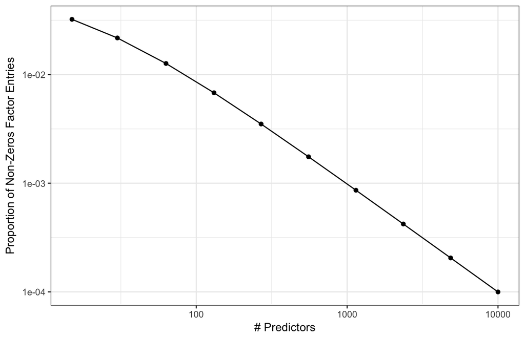

## Percentage of Formula Time Within Functions

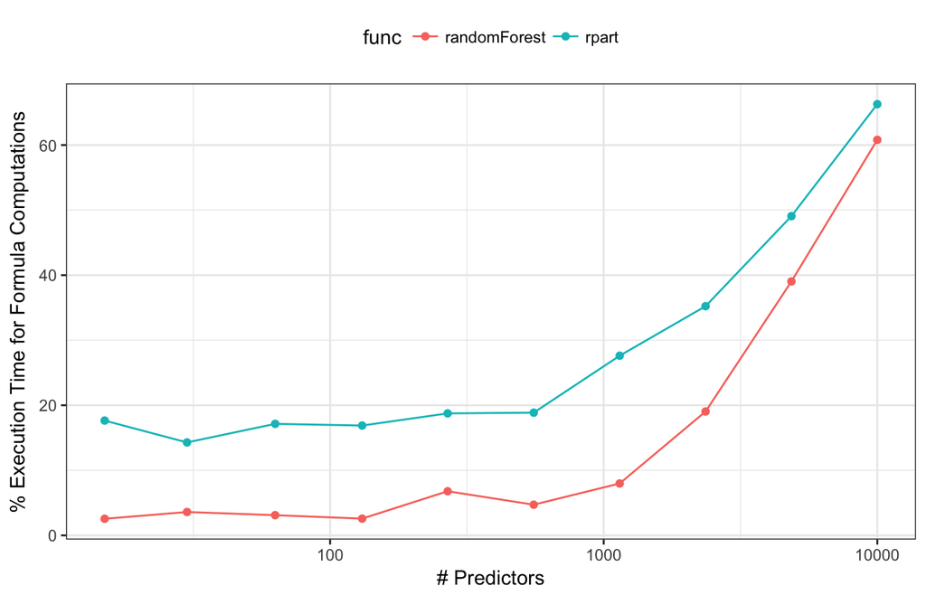

## Problem #5: Variable Roles

Formulas have been re-implemented in different packages for a variety of different reasons:

```r
> # ?lme4::lmer
> # Subjects need to be in the data but are not part of the model
> lmer(Reaction ~ Days + (Days | Subject), data = sleepstudy)
>
> # BradleyTerry2
> # We want to make the outcomes to be a function of a
> # competitor-specific function of reach
> BTm(outcome = 1, player1 = winner, player2 = loser,
+     formula = ~reach[..] + (1 | ..),
+     data = boxers)
>
> # mboost::mob (using the modeltools package for formulas)
> mob(diabetes ~ glucose | pregnant + mass +  age,
+     data = PimaIndiansDiabetes)
```

## Problem #5: Variable Roles

Other issues with multivariate outcomes:

```r
> # ?aggregate the mean of two variables by month
> aggregate(cbind(Ozone, Temp) ~ Month, data = airquality, mean)
>
> # grouped binomial data:
> glm(cbind(events, nonevents) ~ x, family = binomial)
>
> # pls::plsr,
> pls(sensory ~ chemical, data = oliveoil)
> # sensory and chemical are 2D arrays in the oliveoil data frame
```

## Problem #5: Variable Roles

A general list of possible variables roles could be

- outcomes
- predictors
- stratification
- model performance data (e.g. loan amount to compute expected loss)
- conditioning or faceting variables (e.g. [`lattice`](https://cran.r-project.org/package=lattice) or [`ggplot2`](https://cran.r-project.org/package=ggplot2))
- random effects or hierarchical model ID variables
- case weights (*)
- offsets (*)
- error terms (limited to `Error` in the `aov` function)(*)

(*) These can be handled in formulas but are hard-coded into the functions.

## Recipes

We can approach the design matrix and preprocessing steps by first specifying a **sequence of steps**.

1. `price` is an outcome
2. `type` and `sqft` are predictors
3. log transform `price`
4. convert `type` to dummy variables

A recipe is a specification of *intent*.

One issue with the formula method is that it couples the specification for your predictors along with the implementation.

Recipes, as you'll see, separates the *planning* from the *doing*.

## Recipes

A *recipe* can be trained then applied to any data.

```r
> library(recipes)
> library(dplyr)
>
> ## Create an initial recipe with only predictors and outcome
> rec <- recipe(price ~ type + sqft, data = Sacramento)
> rec <- rec %>%
+   step_log(price) %>%
+   step_dummy(type)
>
> rec_trained <- learn(rec, training = Sacramento, retain = TRUE)
```

```
step 1 log training
step 2 dummy training
```

```r
> design_mat <- process(rec_trained, newdata = Sacramento)
```

## Selecting Variables

In the last slide, we used `dplyr`-like syntax for selecting variables such as `step_dummy(type)`.

In some cases, the names of the predictors may not be known at the time when you construct a recipe (or model formula). For example:

- dummy variable columns
- PCA feature extraction when you keep components that capture *X*% of the variability.
- discretized predictors with dynamic bins

`dplyr` selectors can also be used on variables names, such as

```r
> step_spatialsign(matches("^PC[1-9]"), all_numeric(), -all_outcomes())
```

Variables can be selected by name, role, data type, or any [combination of these](https://topepo.github.io/recipes/articles/Selecting_Variables.html).

## Extending

Need to add more preprocessing or other operations?

```r
> standardized <- rec_trained %>%
+   step_center(all_numeric()) %>%
+   step_scale(all_numeric()) %>%
+   step_pca(all_numeric())
>
> ## Only estimate the new parts:
> standardized <- learn(standardized)
```

```
step 1 log [pre-trained]
step 2 dummy [pre-trained]
step 3 center training
step 4 scale training
step 5 pca training
```

If an initial step is computationally expensive, you don't have to redo those operations to add more.

## Available Steps

- **Basic**: [logs](https://topepo.github.io/recipes/reference/step_log.html), [roots](https://topepo.github.io/recipes/reference/step_sqrt.html), [polynomials](https://topepo.github.io/recipes/reference/step_poly.html), [logits](https://topepo.github.io/recipes/reference/step_logit.html), [hyperbolics](https://topepo.github.io/recipes/reference/step_hyperbolic.html)
- **Encodings**: [dummy variables](https://topepo.github.io/recipes/reference/step_dummy.html), ["other"](https://topepo.github.io/recipes/reference/step_other.html) factor level collapsing, [discretization](https://topepo.github.io/recipes/reference/discretize.html)
- **Date Features**: Encodings for [day/doy/month](https://topepo.github.io/recipes/reference/step_date.html) etc, [holiday indicators](https://topepo.github.io/recipes/reference/step_holiday.html)
- **Filters**: [correlation](https://topepo.github.io/recipes/reference/step_corr.html), [near-zero variables](https://topepo.github.io/recipes/reference/step_nzv.html), linear dependencies
- **Imputation**: [bagged trees](https://topepo.github.io/recipes/reference/step_bagimpute.html), [mean](https://topepo.github.io/recipes/reference/step_meanimpute.html)/[mode](https://topepo.github.io/recipes/reference/step_modeimpute.html) imputation,
- **Normalization/Transformations**: [center](https://topepo.github.io/recipes/reference/step_center.html), [scale](https://topepo.github.io/recipes/reference/step_scale.html), [range](https://topepo.github.io/recipes/reference/step_range.html), [Box-Cox](https://topepo.github.io/recipes/reference/step_BoxCox.html), [Yeo-Johnson](https://topepo.github.io/recipes/reference/step_YeoJohnson.html)
- **Dimension Reduction**: [PCA](https://topepo.github.io/recipes/reference/step_pca.html), [kernel PCA](https://topepo.github.io/recipes/reference/step_kpca.html), [ICA](https://topepo.github.io/recipes/reference/step_ica.html), [Isomap](https://topepo.github.io/recipes/reference/step_isomap.html), [data depth](https://topepo.github.io/recipes/reference/step_depth.html) features, [class distances](https://topepo.github.io/recipes/reference/step_classdist.html)
- **Others**: [spline basis functions](https://topepo.github.io/recipes/reference/step_ns.html), [interactions](https://topepo.github.io/recipes/reference/step_interact.html), [spatial sign](https://topepo.github.io/recipes/reference/step_spatialsign.html)

More in process (i.e. autoencoders, more imputation methods, etc.)

One of the [package vignettes](https://topepo.github.io/recipes/articles/Custom_Steps.html) shows how to write your own step functions.

## Extending

Recipes can also be created with different roles manually

```r
> rec <- recipe(x  = Sacramento) %>%
+   add_role(price, new_role = "outcome") %>%
+   add_role(type, sqft, new_role = "predictor") %>%
+   add_role(zip, new_role = "strata")
```

Also, the sequential nature of steps means that they don't have to be R operations and could call other compute engines (e.g. Weka, scikit-learn, Tensorflow, etc. )

We can create wrappers to work with recipes too:

```r
> lin_reg.recipe <- function(rec, data, ...) {
+   trained <- learn(rec, training = data)
+   lm.fit(x = process(trained, newdata = data, all_predictors()),
+          y = process(trained, newdata = data, all_outcomes()), ...)
+ }
```

## An Example

Kuhn and Johnson (2013) analyze a data set where thousands of cells are determined to be well-segmented (WS) or poorly segmented (PS) based on 58 image features. We would like to make predictions of the segmentation quality based on these features.

```r
> library(dplyr)
> library(caret)
> data("segmentationData")
>
> seg_train <- segmentationData %>%
+   filter(Case == "Train") %>%
+   select(-Case, -Cell)
> seg_test  <- segmentationData %>%
+   filter(Case == "Test")  %>%
+   select(-Case, -Cell)
```

## A Simple Recipe

```r
> rec <- recipe(Class  ~ ., data = seg_train)
>
> basic <- rec %>%
+   # Correct some predictors for skewness
+   step_YeoJohnson(all_predictors()) %>%
+   # Standardize the values
+   step_center(all_predictors()) %>%
+   step_scale(all_predictors())
>
> # Estimate the transformation and standardization parameters
> basic <- learn(basic, training = seg_train, verbose = FALSE, retain = TRUE)
```

## Principal Component Analysis

```r
> pca <- basic %>% step_pca(all_predictors(), num = 2)
> summary(pca)
```

```
# A tibble: 59 × 4
                  variable    type      role   source
                     <chr>   <chr>     <chr>    <chr>
 1                AngleCh1 numeric predictor original
 2                 AreaCh1 numeric predictor original
 3             AvgIntenCh1 numeric predictor original
 4             AvgIntenCh2 numeric predictor original
 5             AvgIntenCh3 numeric predictor original
 6             AvgIntenCh4 numeric predictor original
 7  ConvexHullAreaRatioCh1 numeric predictor original
 8 ConvexHullPerimRatioCh1 numeric predictor original
 9     DiffIntenDensityCh1 numeric predictor original
10     DiffIntenDensityCh3 numeric predictor original
# ... with 49 more rows
```

## Principal Component Analysis

```r
> pca <- learn(pca)
```

```
step 1 YeoJohnson [pre-trained]
step 2 center [pre-trained]
step 3 scale [pre-trained]
step 4 pca training
```

```r
> summary(pca)
```

```
# A tibble: 3 × 4
  variable    type      role   source
     <chr>   <chr>     <chr>    <chr>
1    Class nominal   outcome original
2      PC1 numeric predictor  derived
3      PC2 numeric predictor  derived
```

```r
> pca <- process(pca, newdata = seg_test, everything())
```

## Principal Component Analysis

```r
> pca
```

```
# A tibble: 1,010 × 3
    Class       PC1       PC2
   <fctr>     <dbl>     <dbl>
 1     PS  4.857002 -5.850788
 2     PS  3.275265 -1.507823
 3     WS -7.028189 -1.772475
 4     WS -6.955668 -2.080306
 5     PS  6.521270 -3.773029
 6     WS  2.865220  1.655068
 7     WS  2.719588  0.432604
 8     WS -3.010832  1.937252
 9     PS  6.911928 -3.826389
10     PS -2.277258 -3.530858
# ... with 1,000 more rows
```

```r
> ggplot(pca, aes(x = PC1, y = PC2, color = Class)) + geom_point(alpha = .4)
```

## Principal Component Analysis

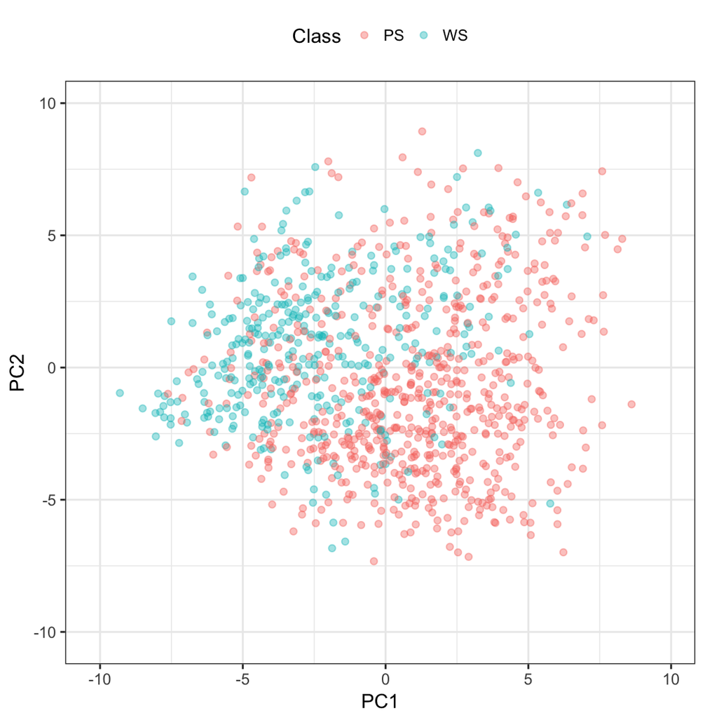

## Kernel Principal Component Analysis

```r
> kern_pca <- basic %>%
+   step_kpca(all_predictors(), num = 2,
+             options = list(kernel = "rbfdot",
+                            kpar = list(sigma = 0.05)))
>
> kern_pca <- learn(kern_pca)
```

```
step 1 YeoJohnson [pre-trained]
step 2 center [pre-trained]
step 3 scale [pre-trained]
step 4 kpca training
```

```r
> kern_pca <- process(kern_pca, newdata = seg_test, everything())
```

## Kernel Principal Component Analysis

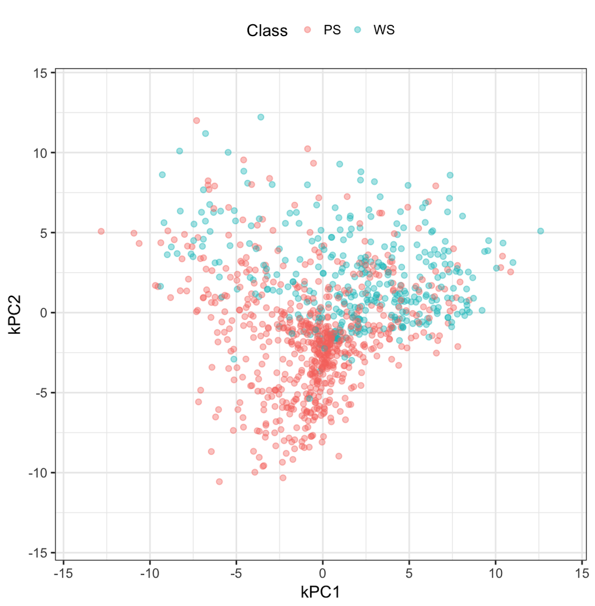

## Distance to Each Class Centroid

```r
> dist_to_classes <- basic %>%
+   step_classdist(all_predictors(), class = "Class") %>%
+   # Take log of the new distance features
+   step_log(starts_with("classdist"))
>
> dist_to_classes <- learn(dist_to_classes, verbose = FALSE)
>
> # All variables are retained plus an additional one for each class
> dist_to_classes <- process(dist_to_classes, newdata = seg_test, matches("[Cc]lass"))
> dist_to_classes
```

```
# A tibble: 1,010 × 3
    Class classdist_PS classdist_WS
   <fctr>        <dbl>        <dbl>
 1     PS     1.530814     1.736136
 2     PS     1.352474     1.461523
 3     WS     1.711062     1.529533
 4     WS     1.754704     1.610803
 5     PS     1.472574     1.653600
 6     WS     1.481809     1.471768
 7     WS     1.493837     1.548758
 8     WS     1.553071     1.396700
 9     PS     1.535125     1.707483
10     PS     1.547865     1.572808
# ... with 1,000 more rows
```

## Distance to Each Class

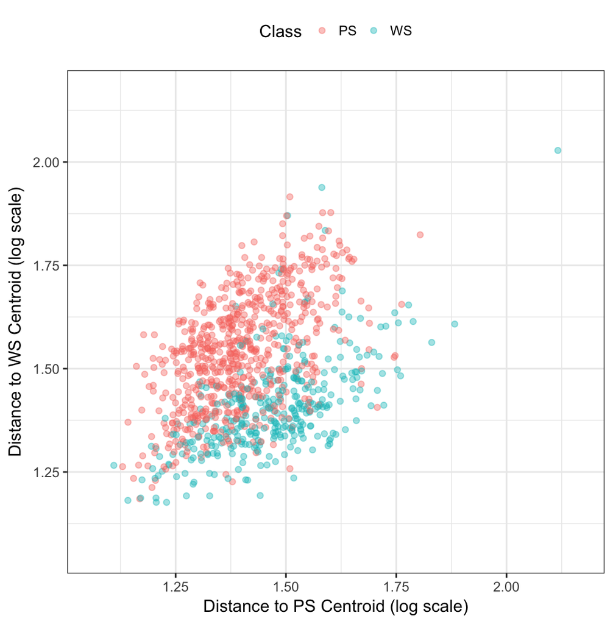

## Next Steps

- Get it on CRAN once `dplyr` and `rlang` are updated
- Add more steps
- `caret` methods for recipes (instead of using `preProcess`):

```r
model1 <- train(recipe, data = data, method, ...)
```

as an alternative to

```r
model2 <- train(x, y, method, preProcess, ...) # or
modely <- train(y ~ x1 + x2, data = data, method, preProcess, ...)
```

## Thanks

ODSC for the invitation to speak

RStudio for enabling me to work on modeling full time